# **Medidas de dispersión**

Practical statistic with R - Chapter 1

La variabilidad, también conocida como dispersión, mide si los valores de los datos son apiñados o esparcidos. Las medidas de dispersión entregan información sobre la variación de la variable. Pretenden resumir en un solo valor la dispersión que tiene un conjunto de datos. Las medidas de dispersión más utilizadas son: rango de variación, varianza, desviación estándar, coeficiente de variación

## **Desviación media absoluta**

Promediar las desviaciones en sí no nos diría mucho: Las desviaciones negativas se compensarian con las desviaciones positivas. De hecho, la suma de las desviaciones de la media es precisamente cero. En cambio, un enfoque simple es tomar el promedio del valor absoluto valores de las desviaciones de la media.

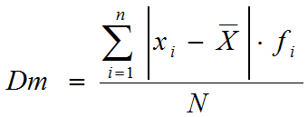

## **Desviación estandar**

La desviación estándar (en inglés “standard deviation”; SD) es una medida de la dispersión de los datos, cuanto mayor sea la dispersión mayor es la desviación estándar, si no hubiera ninguna variación en los datos, es decir, si fueran todos iguales, la desviación estándar sería cero. La desviación estándar cuantifica la dispersión alrededor de la media aritmética. Informa de la media de distancias que tienen los datos respecto de su media aritmética.

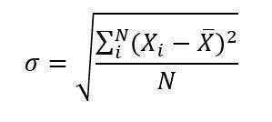